# Scenario Update IIIQ2025

# 1 Frame of Reference

REF-E scenarios over the time horizon 2025–2050 (with projections up to 2060) are developed by MBS Consulting experts using proprietary tools and market expertise. These scenarios are based on econometric and structural models, combined with expert insights, detailed regulatory knowledge, and rigorous monitoring of market dynamics.

Gas and electricity forecasts consider various geopolitical and economic hypotheses stemming from regulatory, financial, and fundamental adjustments to disruptions caused by both the pandemic and the war in Ukraine. These factors are viewed as key determinants of the future equilibrium in energy markets.

The current scenario update incorporates climate variable trends that align with historical averages.

In this context, we have defined three scenarios:

- The **Low RES scenario**: Characterized by persistently high fuel and power prices amid negative or stagnant economic growth, this scenario hampers investments and slows the energy transition process.
- In the **Reference scenario**: Marked by progress in the energy transition process, this scenario reflects a diversification of energy sources supported by existing policies. Combined with efficiency improvements, it maintains the energy market on a transformational path. Economic growth is expected to recover gradually over the next two years.
- The **High RES scenario**: This scenario assumes favorable weather conditions and a rapid energy transition, facilitated by low inflation and a faster economic recovery. These factors would reduce demand for power and fossil fuels over the next few years, limiting upward pressure on energy prices and potentially driving a downward acceleration.

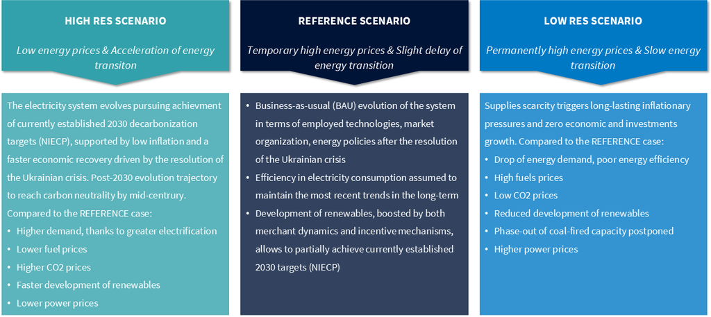

## 1.1 Energy Transition in the Spotlight: Demand Stagnation, MACSE and FERX Results and Price Dynamics

*Gas Prices Ease, but Risk for Market Tightness Persists Ahead of the Winter Season*

Gas prices have declined over the past three months, settling at €40/MWh, reflecting stable LNG supplies, combined with muted demand competition. Europe’s LNG imports remained robust as Asian demand growth slowed, with China’s LNG intake being capped by higher domestic production, expanded Russian pipeline flows, and growing renewable capacity. This dynamic led to a steeper-than-expected price decline, although in line with our expectations for an overall downward trajectory.

Nevertheless, structural risks persist in the short-term. Geopolitical uncertainty continues to add a risk premium, while European storage levels are 10% lower than the historical average. With limited new LNG supply due to come online in the near term, winter price volatility remains a key concern. Average gas transport costs are expected to remain high in the short to medium term, approximately at €4/MWh, mainly due to storage-related charges and the continued impact of White Certificate and efficiency components. A gradual decline below €4/MWh is projected after 2028, consistent with the anticipated normalization of gas prices. The latest ARERA update on tariff components (Resolution 429/2025/R/Com) confirms that current funds are sufficient to support storage-related measures, thereby aligned with our forecast assumptions. Our base-case scenario remains unchanged. We maintain an average PSV price forecast close to €40/MWh for 2025, gradually declining toward €35/MWh in 2026 as new regasification capacity, including the Ravenna FSRU, comes fully online. From 2027 onward, the commissioning of additional liquefaction capacity, primarily from the US and Qatar, is anticipated to consolidate a structurally long supplied market, driving European prices toward the €27/MWh threshold by 2030.

Our updated CO₂ price outlook incorporates recent market trends, with downward revisions of nearly €30/tCO₂ in the High RES scenario and €1/tCO₂ in the Reference case for 2025. 2026 values report a similar update, with a €20/ tCO₂ reduction to High RES projections, while the Reference value remains approximately aligned. Weak industrial activity and subdued auction demand have increased the TNAC, temporarily delaying the expected tightening effect of ETS reforms.

On the macroeconomic side, short-term GDP growth forecasts have been revised slightly downward amid persistent geopolitical tensions and rising trade barriers. The combination of weaker exports and stagnant domestic demand continues to weigh on industrial output.

*FER-X 2025 results and progress in installed capacity foster optimism, yet the achievement of burden-sharing targets remains uncertain*

Renewable energy installations continue to follow a growth trajectory, though at a slower pace compared to 2024. In the first nine months of 2025, photovoltaic capacity additions reached 4100 MW, marking a 3% year-on-year slowdown in growth, while wind installations totaled 370 MW, with a sharper deceleration of 19.4%. The reduced momentum likely reflects transitional delays ahead of the FERX auction, which was awaited by the market and concluded in September 2025. On the generation side, solar output continues to exceed 2024 levels, largely driven by the contribution of newly installed capacity. Wind generation, by contrast, remains more volatile: monthly output has been hovering around last year’s levels, indicating that recent capacity additions have not yet translated into a sustained increase in output. These trends are consistent with the evidence presented in the IIQ MBS report. Under our Reference scenario, RES generation is projected to cover 51% of electricity demand by 2030, reaching the 63% target only by 2038. This gap persists despite a downward revision of demand expectations for 2025-2030 in this release, reflecting weaker consumption in early 2025 and a stagnating industrial sector. The updated outlook underscores the need for faster deployment and stronger policy support.

We have revised our short-term installed capacity projections upward, as installation activity in 2025 has outpaced earlier expectations. Nonetheless, we reaffirm our medium- and long-term outlook, which envisages a broadly positive growth path supported by a pipeline exceeding 20 GW in advanced authorization stages (excluding projects already participating in the FERX 2025 auction). However, projected capacity levels are still expected to fall short of NIECP targets for both 2030 and 2040. In this context, the outcomes of the FER-X 2025 auction represent a key test for the policy and market dynamics that will shape the next phase of renewable deployment.

The FER-X 2025 auction attracted around 12 GW of renewable project bids, largely dominated by solar and concentrated in the South and Sicily, in line with our expectations. These bids were drawn from a subset of approximately 18 GW of potential participants, identified by applying commercial and technical filters to a broader pool of 30 GW of projects with final authorization or a positive VIA. Of this subset, roughly 5 GW were expected to pursue alternative routes such as Energy Release 2.0 or PPAs.

Strong participation reinforces confidence in the medium-term outlook for RES-E deployment. However, only the publication of auction rankings will reveal whether the measure has effectively supported burden-sharing objectives. In particular, it remains to be seen whether capacity has been steered toward Northern Italy, or whether the higher cost competitiveness and strong presence of Southern projects have resulted in geographically unbalanced allocation. Despite hosting nearly half of Italy’s installed capacity, the North faces a substantial pipeline gap, with around 15 GW still needed to attain 2030 NIECP targets, amid just over 5 GW expected in other macrozones.

These dynamics are especially relevant looking ahead of Definitive FER-X approval, which will require expert calibration of operational rules. We estimate that roughly 20 GW are eligible for upcoming auctions, predominantly solar projects in the South. In this context, effective territorial differentiation mechanisms are essential. Our analysis of pre-Commission drafts indicated that neither zonal coefficients nor merit-order correctives alone would ensure a geographically balanced allocation.

*Rising Solar Output Deepens Intraday Price Distortions, Weighing on RES-E Captured Prices*

The growing penetration of solar generation is increasingly reshaping hourly price dynamics, deepening midday price troughs and amplifying profile skewness compared to the profile elaborated as of IIQ25 release. Captured prices for solar and, more broadly, RES-E technologies are anticipated to come under increasing downward pressure, particularly over the medium to long term. These evolving market conditions reinforce the strategic importance of flexibility assets such as storage, which are essential to stabilizing revenues and supporting system integration.

*MACSE to Drive Southern Deployment While Northern Regions Position for Merchant Storage Growth*

The first MACSE auction, held on 30 September 2025, awarded 10 GWh of electrochemical storage capacity, fully covering the volume made available, at an average price close to €13,000/MWh-year, which is well below the regulatory cap of €37,000/MWh-year. As anticipated with preliminary analyses, competition was intense, with more than 35–40 GWh of offers submitted, over three times the required capacity, confirming a strong and dynamic market. Most awarded projects are located in Southern regions, where 7 GWh were allocated in the South and Calabria, 2 GWh in the Centre-South, and 0.5 GWh each in Sicily and Sardinia.

According to our estimates, the awarded tariffs are consistent with internal rates of return (IRR) below 5%, net of leverage effects. These returns are compatible with CAPEX levels that have fallen by roughly 40% since late 2024. The MACSE mechanism therefore appears particularly suited to investors seeking long-term, stable cash flows, such as vertically integrated utilities, rather than developers focused on single-asset returns. The auction design, which remunerates capacity based on the actual energy deliverable (MWh/year), favored larger and longer-duration systems, typically ranging from six to eight hours, which benefit from economies of scale.

Our BESS projections are broadly consistent with the MACSE outcomes in terms of total capacity awarded, although some discrepancies remain at the zonal level, with capacity allocation in Southern zones being underestimated compared to the auction results. As of IIIQ25, our BESS projections remain aligned with IIQ25 estimates, as the detailed zonal results of the MACSE auction have not yet been incorporated due to timing. We also confirm our medium- and long-term outlook. The Italian storage market continues to expand, supported by a robust pipeline of utility-scale projects. 10 GW of capacity, beyond that participating to the MACSE auction has already received authorization while over 16.6 GW of additional capacity is currently under evaluation, representing the eligible pool for future MACSE rounds beyond 2025 and forming the backbone of future installations. Based on MACSE outcomes and Capacity Market dynamics, we project over 20 GWh of large-scale battery capacity to be deployed by 2028. In line with the NIECP target of 72 GWh of new storage by 2030, utility-scale systems are expected to concentrate in Southern regions, where renewable intermittency is greatest. Northern zones will emerge as hubs for merchant storage, driven by sustainable market revenues and the gradual saturation of incentive-based capacity in the South. Overall, Italy’s total installed battery capacity is projected to reach around 88 GWh by 2030.

# 2 Key Figures

[output not shown]

| BALANCE (TWh) | Reference 2025 | Reference 2030 | Reference 2040 | Reference 2050 | High RES 2025 | High RES 2030 | High RES 2040 | High RES 2050 | Low RES 2025 | Low RES 2030 | Low RES 2040 | Low RES 2050 |
| --- | --- | --- | --- | --- | --- | --- | --- | --- | --- | --- | --- | --- |
| Demand | 310,4 | 330,7 | 360,4 | 387,5 | 313,6 | 345,8 | 373,0 | 393,9 | 308,3 | 319,0 | 340,2 | 353,1 |
| Net import | 52,1 | 46,4 | 47,5 | 47,3 | 52,2 | 46,1 | 45,3 | 45,1 | 52,1 | 47,0 | 48,4 | 48,3 |
| Hydro | 45,9 | 46,8 | 49,6 | 52,2 | 45,9 | 47,0 | 50,2 | 52,9 | 45,9 | 46,6 | 48,8 | 51,0 |
| Renewables | 92,9 | 121,4 | 191,5 | 263,4 | 93,5 | 148,3 | 233,7 | 320,7 | 90,8 | 103,5 | 136,1 | 172,5 |
| Natural Gas | 90,8 | 96,6 | 74,3 | 42,4 | 94,0 | 86,6 | 49,3 | 19,2 | 91,4 | 96,5 | 94,2 | 82,9 |
| Coal | 5,1 | 0,0 | 0,0 | 0,0 | 4,4 | 0,0 | 0,0 | 0,0 | 3,5 | 4,3 | 0,0 | 0,0 |
| Overgeneration | -0,9 | -0,8 | -4,0 | -6,1 | -1,0 | -1,8 | -5,3 | -13,9 | -0,8 | -0,2 | -0,7 | -0,8 |

| COMMODITIES | Reference 2025 | Reference 2030 | Reference 2040 | Reference 2050 | High RES 2025 | High RES 2030 | High RES 2040 | High RES 2050 | Low RES 2025 | Low RES 2030 | Low RES 2040 | Low RES 2050 |
| --- | --- | --- | --- | --- | --- | --- | --- | --- | --- | --- | --- | --- |
| PSV (€/MWh) | 40,5 | 27,3 | 25,1 | 25,1 | 36,4 | 10,4 | 10,1 | 10,1 | 47,0 | 55,5 | 43,4 | 43,4 |
| Coal (€/MWh) | 13,3 | 13,8 | 7,8 | 7,8 | 11,9 | 6,9 | 3,9 | 3,9 | 14,0 | 16,8 | 10,3 | 10,3 |
| CO2 (€/ton) | 74,7 | 107,3 | 123,0 | 139,7 | 77,8 | 133,1 | 147,2 | 160,5 | 66,8 | 72,3 | 93,0 | 113,0 |

| ELECTRICITY PRICES (€/MWh) | Reference 2025 | Reference 2030 | Reference 2040 | Reference 2050 | High RES 2025 | High RES 2030 | High RES 2040 | High RES 2050 | Low RES 2025 | Low RES 2030 | Low RES 2040 | Low RES 2050 |
| --- | --- | --- | --- | --- | --- | --- | --- | --- | --- | --- | --- | --- |
| Fuel variable cost - CCGT 53% | 84,5 | 56,9 | 52,2 | 52,2 | 75,9 | 21,7 | 21,1 | 21,1 | 97,9 | 115,6 | 90,5 | 90,5 |
| Logistic variable cost - CCGT 53% | 9,0 | 5,2 | 3,4 | 3,4 | 9,0 | 5,2 | 3,4 | 3,4 | 9,0 | 7,0 | 3,4 | 3,4 |
| ETS impact - CCGT 53% | 28,1 | 40,4 | 46,3 | 52,6 | 29,3 | 50,1 | 55,4 | 60,4 | 25,1 | 25,2 | 35,0 | 42,5 |
| Clean Spark Spread - CCGT 53% | -3,1 | -4,8 | -6,5 | -29,8 | -2,0 | -5,8 | -6,7 | -19,0 | -3,6 | -5,4 | -4,1 | -13,7 |

| ZONAL PRICES (€/MWh) | Reference 2025 | Reference 2030 | Reference 2040 | Reference 2050 | High RES 2025 | High RES 2030 | High RES 2040 | High RES 2050 | Low RES 2025 | Low RES 2030 | Low RES 2040 | Low RES 2050 |
| --- | --- | --- | --- | --- | --- | --- | --- | --- | --- | --- | --- | --- |
| PUN | 118,6 | 97,7 | 95,4 | 78,4 | 112,3 | 71,2 | 73,2 | 65,8 | 128,5 | 143,0 | 124,8 | 122,6 |
| North | 119,8 | 98,3 | 95,7 | 78,8 | 112,8 | 72,3 | 74,7 | 67,7 | 129,7 | 143,4 | 125,0 | 122,7 |
| Centre-North | 116,5 | 96,7 | 95,1 | 78,7 | 112,3 | 70,6 | 71,3 | 66,5 | 126,8 | 143,0 | 125,0 | 122,7 |
| Centre-South | 115,6 | 96,9 | 95,1 | 78,7 | 108,9 | 70,6 | 71,3 | 66,5 | 126,1 | 142,8 | 124,7 | 122,6 |
| South | 114,2 | 96,6 | 95,1 | 78,7 | 107,2 | 68,6 | 71,3 | 66,2 | 124,5 | 142,8 | 124,4 | 122,6 |
| Sicily | 114,6 | 97,1 | 95,0 | 76,1 | 107,1 | 68,4 | 70,4 | 52,4 | 124,4 | 142,8 | 124,3 | 122,5 |
| Sardinia | 113,9 | 96,2 | 94,4 | 71,0 | 107,1 | 67,9 | 71,2 | 49,8 | 121,8 | 136,3 | 124,7 | 122,2 |
| Calabria | 114,2 | 96,6 | 95,1 | 78,7 | 107,2 | 68,6 | 71,3 | 66,2 | 124,5 | 142,8 | 124,4 | 122,6 |

| CAPTURED PRICES PV FIXED TILT (€/MWh) | Reference 2025 | Reference 2030 | Reference 2040 | Reference 2050 | High RES 2025 | High RES 2030 | High RES 2040 | High RES 2050 | Low RES 2025 | Low RES 2030 | Low RES 2040 | Low RES 2050 |
| --- | --- | --- | --- | --- | --- | --- | --- | --- | --- | --- | --- | --- |
| North | 100,0 | 74,3 | 60,5 | 35,8 | 95,3 | 52,2 | 54,8 | 42,6 | 105,4 | 111,1 | 88,7 | 74,1 |
| Centre-North | 90,1 | 70,2 | 60,5 | 36,5 | 94,4 | 48,9 | 51,5 | 42,5 | 96,6 | 110,7 | 89,9 | 75,4 |
| Centre-South | 87,2 | 70,6 | 60,9 | 36,8 | 83,8 | 49,3 | 51,7 | 42,6 | 93,9 | 109,9 | 89,5 | 75,9 |
| South | 83,8 | 69,8 | 60,3 | 36,1 | 79,8 | 47,5 | 51,4 | 42,7 | 90,0 | 109,5 | 88,1 | 74,9 |
| Sicily | 83,4 | 70,2 | 60,5 | 33,1 | 79,7 | 47,5 | 50,1 | 30,0 | 90,1 | 109,9 | 88,4 | 75,4 |
| Sardinia | 84,2 | 69,6 | 58,7 | 26,0 | 80,7 | 48,3 | 51,0 | 25,5 | 89,1 | 99,9 | 88,6 | 74,0 |
| Calabria | 82,6 | 69,3 | 59,8 | 35,6 | 79,0 | 47,2 | 50,6 | 42,2 | 88,7 | 108,8 | 87,8 | 74,6 |

[output not shown]

| CAPTURED PRICES WIND ONSHORE (€/MWh) | Reference 2025 | Reference 2030 | Reference 2040 | Reference 2050 | High RES 2025 | High RES 2030 | High RES 2040 | High RES 2050 | Low RES 2025 | Low RES 2030 | Low RES 2040 | Low RES 2050 |
| --- | --- | --- | --- | --- | --- | --- | --- | --- | --- | --- | --- | --- |
| North | 122,4 | 93,8 | 85,3 | 68,0 | 114,2 | 68,1 | 66,3 | 65,4 | 133,3 | 140,4 | 118,4 | 114,8 |
| Centre-North | 116,8 | 90,6 | 80,0 | 62,9 | 112,7 | 64,1 | 55,7 | 57,9 | 130,0 | 139,6 | 116,7 | 111,6 |
| Centre-South | 110,9 | 86,5 | 75,8 | 59,2 | 103,9 | 61,0 | 54,4 | 55,2 | 122,4 | 133,3 | 112,6 | 106,8 |
| South | 108,7 | 85,9 | 76,3 | 60,9 | 100,7 | 56,2 | 54,3 | 54,1 | 120,1 | 133,8 | 112,7 | 109,1 |
| Sicily | 107,1 | 83,8 | 74,1 | 54,4 | 96,4 | 53,4 | 50,9 | 29,6 | 121,6 | 132,5 | 109,2 | 106,8 |
| Sardinia | 107,7 | 83,8 | 71,5 | 44,6 | 97,4 | 55,3 | 52,9 | 26,6 | 114,5 | 122,5 | 110,6 | 106,3 |
| Calabria | 108,7 | 86,0 | 76,3 | 60,9 | 100,7 | 56,1 | 54,4 | 54,1 | 120,0 | 133,8 | 112,6 | 109,1 |

| CAPTURED PRICES WIND OFFSHORE (€/MWh) | Reference 2025 | Reference 2030 | Reference 2040 | Reference 2050 | High RES 2025 | High RES 2030 | High RES 2040 | High RES 2050 | Low RES 2025 | Low RES 2030 | Low RES 2040 | Low RES 2050 |
| --- | --- | --- | --- | --- | --- | --- | --- | --- | --- | --- | --- | --- |
| North | 0,0 | 94,6 | 85,9 | 68,7 | 0,0 | 68,0 | 66,8 | 71,7 | 0,0 | 142,3 | 119,4 | 117,2 |
| Centre-North | 0,0 | 92,5 | 79,0 | 63,2 | 0,0 | 65,1 | 55,2 | 60,9 | 0,0 | 142,0 | 117,6 | 114,2 |
| Centre-South | 0,0 | 90,3 | 77,1 | 63,2 | 0,0 | 63,4 | 55,4 | 61,4 | 0,0 | 139,1 | 116,0 | 114,3 |
| South | 111,9 | 88,4 | 81,2 | 66,7 | 103,5 | 58,2 | 59,3 | 57,0 | 124,4 | 137,0 | 116,6 | 114,6 |
| Sicily | 0,0 | 90,0 | 82,2 | 62,7 | 0,0 | 59,7 | 55,8 | 34,2 | 0,0 | 139,7 | 117,0 | 115,7 |
| Sardinia | 0,0 | 90,5 | 83,5 | 58,2 | 0,0 | 61,5 | 60,2 | 34,3 | 0,0 | 131,1 | 118,6 | 116,5 |
| Calabria | 0,0 | 0,0 | 81,2 | 66,7 | 0,0 | 0,0 | 59,3 | 57,0 | 0,0 | 0,0 | 116,6 | 114,6 |

# 3 Macroeconomic Context

## 3.1 GDP

**GEOPOLITICAL TENSIONS AND TRADE CONFLICTS, FURTHER AGGRAVATED BY THE IMPOSITION OF COMMERCIAL TARIFFS THAT HAVE SEVERELY AFFECTED ITALIAN EXPORTS, ARE SHAPING A SHORT-TERM CONTEXT CHARACTERIZED BY LIMITED ECONOMIC GROWTH, SUSTAINED PRIMARILY BY INVESTMENTS LINKED TO THE NRRP. EXCLUDING THESE FUNDS, THE INDUSTRIAL SECTOR IS EXPERIENCING A PROLONGED PHASE OF STAGNATION, WITH NO SIGNS OF RECOVERY EXPECTED IN THE COMING MONTHS. IN THE MEDIUM TO LONG TERM, A GRADUAL IMPROVEMENT OF THE ECONOMIC SITUATION IS ANTICIPATED, SUPPORTED BY THE PROGRESSIVE STABILISATION OF THE GLOBAL MACROECONOMIC ENVIRONMENT**

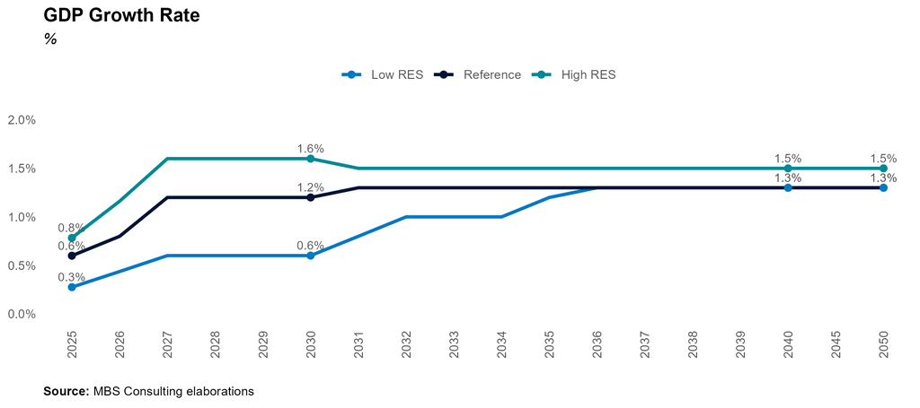

#### 25-26

In the short term, the most recent data confirmed our previous forecast worsening, due to the limited industrial output, a strong decrease in export and subdued consumption. In the next two years is confirmed our forecasts of a weak GDP growth below the 1%, with an expected increase of 0.6% in 2025 and a slightly more consistent growth in 2026 (0.8%).

#### 31-50

Over the long term, the Reference and High Res scenarios assume that economic growth will reach a steady pace, supported by sustained progress in investment and reform. In contrast, the Low Res scenario captures the prolonged effects of disruptions in key investment areas, which continue to weigh on overall economic performance.

#### Main updates

GDP growth forecast remains in line with our previous market update.

## 3.2 Inflation rate

**DESPITE THE DETERIORATION OF THE GLOBAL MACROECONOMIC ENVIRONMENT AND THE INTENSIFICATION OF FACTORS THAT HEIGHTEN THE RISK OF PRICE PRESSURES, THE MOST RECENT INFLATION DATA INDICATE THAT NO SIGNIFICANT INCREASE IN THE INFLATION RATE HAS YET MATERIALIZED. IN THE SHORT TERM, INFLATION IS EXPECTED TO REMAIN BELOW 2%, BEFORE CONVERGING TOWARD THIS LEVEL FROM THE MEDIUM TERM ONWARD**

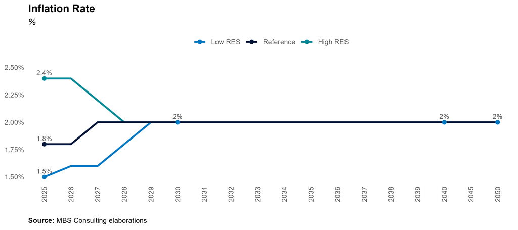

#### 25-26

Heightened geopolitical tensions are expected to lead to a stronger increase in prices in the short term compared to 2024, when monetary policy measures supported a disinflationary trajectory. In 2025 and 2026, inflation is projected to remain below the 2% threshold (at around 1.8% in both years). The outlook is subject to a high degree of uncertainty, largely linked to the implementation of import tariffs recently announced by the United States. These measures could exert significant upward pressure on prices in the near term, potentially altering short-term inflation dynamics and projections.

#### 27-30

In the medium term, a gradual increase is expected to bring annual inflation growth up to 2%, followed by a period of stabilization around that level.

#### 31-50

Long-term assumptions envisage the inflation rate to stabilize at around 2%, in line with the ECB’s medium term inflation target.

#### Main updates

Short-term inflation rates remained in line with our previous market update.

# 4 Commodities

## 4.1 Natural Gas

### 4.1.1 LNG

**GLOBAL LNG DEMAND WILL CONTINUE TO GROW, LED BY EUROPE AND ASIA, WHILE NEW LIQUEFACTION CAPACITY COMING ONLINE FROM 2027 WILL OUTPACE CONSUMPTION GROWTH. THE RESULTING WIDER SUPPLY-DEMAND MARGIN IS EXPECTED TO EASE MARKET TIGHTNESS, WITH GLOBAL LNG PRICES GRADUALLY DECLINING**

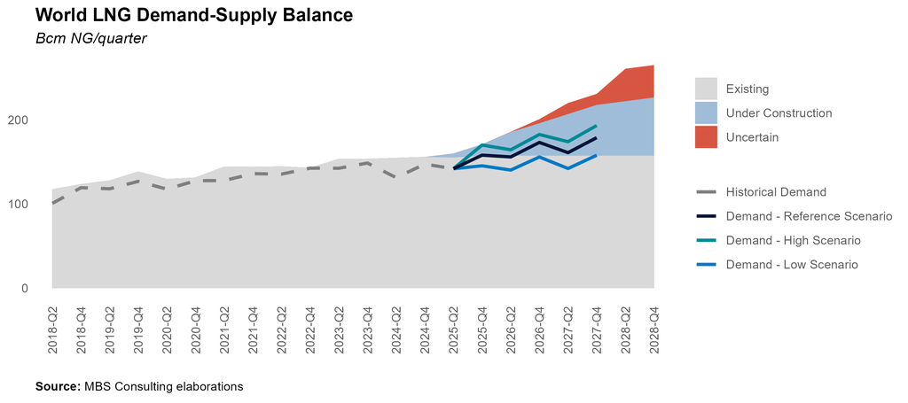

#### 25-26

Global LNG demand is expected to rise over 5% in 2025 to around 600 Bcm, reaching about 650 Bcm in 2026. Growth is led by Europe, which must replace roughly 30 Bcm of lost Russian pipeline gas and refill storage to meet energy security goals. In Asia, demand growth is slower as China increases Russian pipeline imports, boosts domestic production, and expands renewables, reducing LNG needs. Southeast Asia adds demand through economic growth but remains price sensitive. With limited new supply, market tightness remains likely, potentially lifting winter prices.

#### 27-30

Global LNG demand is expected to exceed 650 Bcm by 2027, before slowing to below 5% annual growth as renewable generation expands and energy efficiency gains accelerate. From 2027, a significant new wave of supply (mainly from the US and Qatar) will enter the market. This additional capacity is likely to ease current tightness, supporting a gradual rebalancing and normalization of global LNG prices.

#### 31-50

In the long term, pressure on the LNG market is expected to ease as new capacity expands, and green energy commitments take effect.

#### Main updates

We maintain our global LNG market outlook. Demand remains on track with earlier expectations, as stronger growth in Europe and parts of Asia offsets slower demand in China.

### 4.1.2 TTF Price

**WEAK ECONOMIC ACTIVITY, CONTINUED IMPROVEMENTS IN ENERGY EFFICIENCY, AND THE EXPANSION OF RENEWABLE POWER GENERATION PREVENT GAS DEMAND FROM RECOVERING TO PRE-CRISIS LEVELS. OVER THE LONG TERM, EUROPE’S DECARBONIZATION EFFORTS ARE EXPECTED TO ACCELERATE DEMAND DECLINES, DRIVING TTF PRICES TOWARDS A LOWER TREND OF AROUND 25 €/MWH**

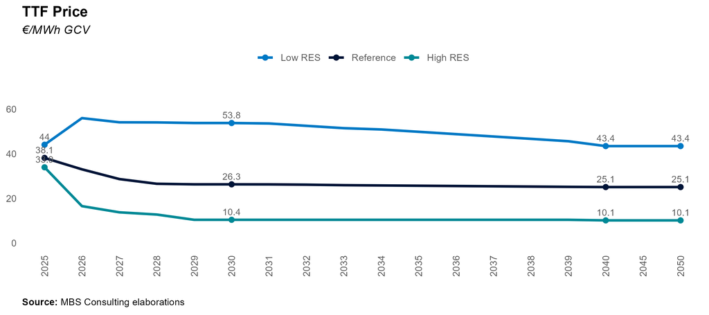

#### 27-30

Significant increases in new liquefaction capacity in US and Qatar would lead to a gas price normalization from 2027 onwards. Assuming a ramp up in global LNG supplies and an acceleration of the energy transition, European gas prices are projected to steadily decline below the 30 €/MWh threshold by 2028.

#### 31-50

The European decarbonization process will continue to reduce gas demand, gradually pressuring prices back towards a long-term equilibrium of around 25 €/MWh. In the Low Res scenario, where geopolitical tensions persist and structurally supply issues remain unresolved, prices will likely remain just below 45 €/MWh over the long term. In contrast, effective green policies, supported by economic growth, could push prices significantly lower in the High Res scenario, with the TTF averaging near 10 €/MWh in the long term.

#### Main updates

Both short- and long-term TTF gas price projections remain substantially in line with our previous market assessment. The updated projections incorporate summer prices that were slightly lower than expected, as storage refill proceeded with less difficulty than anticipated.

### 4.1.3 Spread TTF-PSV

**AS PIPED FLOWS FROM NORWAY REMAIN CRUCIAL FOR ADEQUATE DEMAND COVERAGE, THE PSV GAS PRICE IS EXPECTED TO MAINTAIN A PREMIUM OVER THE TTF IN THE SHORT-TO-MEDIUM TERM. IN THE LONG TERM, THE REBALANCING OF FLOWS IS ANTICIPATED TO LEAD TO A GRADUAL NARROWING OF THE SPREAD TOWARDS ZERO**

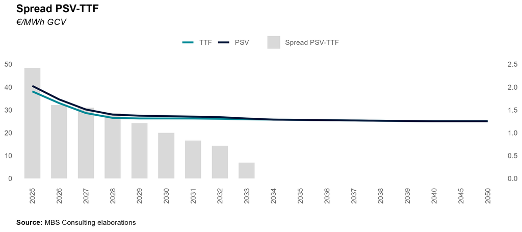

#### 27-30

Flows from the TAP and Algeria, along with LNG arrivals, are expected to partially replace imports from the North in the medium term, leading to a progressive narrowing of the spread to below 1 €/MWh by 2030.

#### 31-50

The PSV-TTF spread is expected to converge towards zero in the long term, as flows rebalance from North to South and LNG, combined with the underlying demand reduction driven by decarbonization, plays a key role.

#### Main updates

The PSV-TTF spread is still expected to remain positive in the short and medium term due to Italy’s continued reliance on piped gas flows from Norway and high transport tariffs. However, it is projected to gradually reduce towards zero in the long run as flows rebalance and LNG plays an increasing role.

### 4.1.4 PSV Price

**THE ITALIAN GAS PRICE REMAINS CLOSELY LINKED TO EUROPEAN HUB LEVELS IN THE SHORT-TO-MEDIUM TERM, WITH PSV TRACKING TTF MOVEMENTS. OVER THE LONG TERM, PSV IS EXPECTED TO ALIGN WITH EUROPEAN PRICES, REACHING AROUND 30 €/MWH BY 2030**

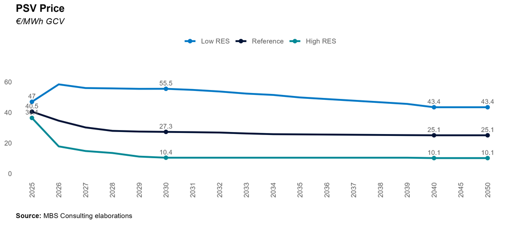

#### 25-26

We still expect PSV yearly averages to remain close to €40/MWh in 2025 and around €35/MWh in 2026, despite weak natural gas demand growth. Conditions for full stabilization of the Italian gas market are unlikely to materialize in the near term, in line with the overall European gas market. The new Ravenna FSRU, with 5 Bcm/y of regasification capacity, is expected to be fully operational by 2026, helping ease some pressure, which will remain high, particularly during winter 2025–2026.

#### 27-30

The PSV is expected to follow the mid-term normalization of European gas prices towards 30 €/MWh by 2030, as a gradual rebalancing of the global gas demand-supply dynamics aligns with the anticipated acceleration of the energy transition.

#### 31-50

The PSV reference price is expected to stabilize, aligning with TTF prices at around 25 €/MWh in the long term.

#### Main updates

As for the TTF, short-term PSV projections remain consistent with our previous market update, incorporating recent summer prices that were slightly lower than expected due to smoother storage refill. The European gas market balance remains fragile, and further gas price recovery cannot be ruled out.

### 4.1.5 Logistics Costs for Italian Gas-Fired Units

**SHORT-TERM GAS LOGISTIC COSTS ARE EXPECTED TO REMAIN HIGH, ABOVE 4 €/MWh(t), REFLECTING EXTRA CHARGES TO OFFSET HIGH GAS PRICE IMPACTS ON CONSUMERS AND SECURE SYSTEM OPERATOR REVENUES. VARIABLE GAS COSTS SHOULD START GRADUALLY DECREASING FROM 2028 ONWRADS, FOLLOWING THE EXPECTED GAS PRICES NORMALIZATION**

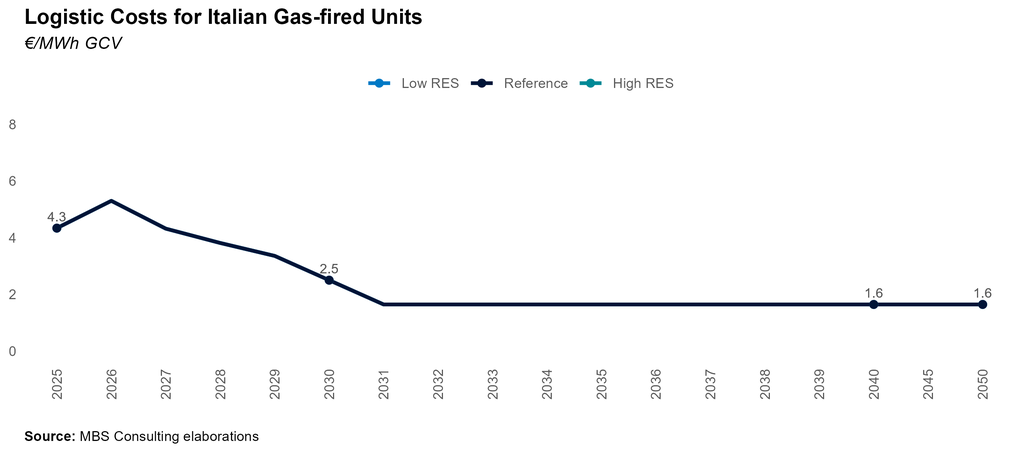

#### 25-28

The variable logistic cost for CCGTs is expected to remain above 4 €/MWh(t) on average in the short-to-medium term, driven by the need to recover extra costs linked to measures mitigating the impact of high prices on consumers and to ensure adequate revenues for gas system operators. With Resolution 429/2025/R/Com, ARERA confirms that current funds are sufficient to cover the costs of the last-resort storage service (STUI), supporting our CRVOS projections. The CRVOS component, which ensures revenues for storage operators, is expected to gradually normalize to just above 1.5 €/MWh(t) from winter 2026/27, reflecting a steady return to pre-crisis levels. However, ARERA also highlighted that costs covered by the RET component (including White Certificates and energy efficiency measures) remain under pressure. This reinforces our view that RET is expected to remain high at around 2.6 €/MWh(t) throughout at least 2026.

#### Main updates

The variable transport charges forecast incorporates the latest regulator interventions to mitigate the recent commodities surge on bills.

## 4.2 EU ETS

### 4.2.1 CO2 Allowances Price

**THE ETS REFORM AIMS AT SUPPORTING A RAISE IN CO2 PRICE BY TIGHTENING THE EMISSIONS CERTIFICATES MARKET THROUGH A COMBINATION OF SUPPLY CURTAILMENT AND DEMAND-INCREASING MEASURES. THE INCLUSION OF NEW SECTORS, SUCH AS THE MARITIME, WILL CONTRIBUTE TO SUSTAINING THE ENVISIONED PRICE INCREASES**

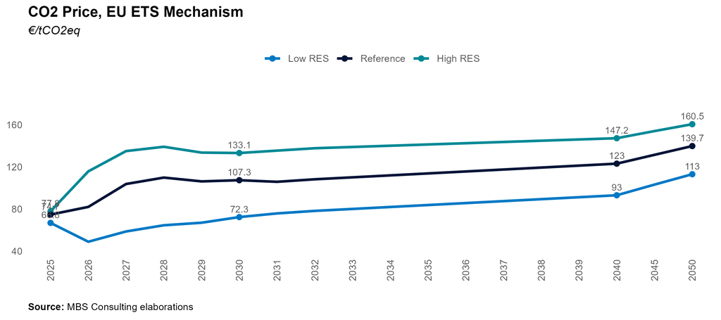

#### 25-26

After weak price growth in early 2025, ETS certificate prices have risen in recent months, driven by the start of allowance withdrawals under the Market Stability Reserve and expectations of higher future demand. CO₂ prices are now converging toward the 2025 forecast of around €75 per ton. In 2026, prices are expected to rise further with the inclusion of maritime emissions and the phase-out of free aviation allowances, reaching about €82 per ton.

#### 27-30

Despite the delay in price growth observed in 2025, the market mechanism is expected to remain effective over the medium term, with CO₂ prices projected to exceed €105/ton before 2030.

#### 31-50

The EU ETS is expected to transition to a fully auction-based system, phasing out free allocations entirely, including Hard-to-Abate sectors. The scheme’s coverage could be broadened to encompass additional industries currently excluded from its scope. Under the assumption of full implementation of the planned regulatory framework, CO₂ prices are projected to stabilize above €120 per ton after 2040. In the High Res scenario, which envisions a more stringent EU emissions reduction trajectory, prices could rise further, approaching €150 per ton.

#### Main updates

Short-term CO₂ price forecast remains in line with our previous market update.

# 5 Energy Mix

## 5.1 Day-Ahead Market Energy Balance

### 5.1.1 Reference Scenario

**IN THE SHORT TERM, IMPORTS AND RES-E DOMINATE THE MIX AS DEMAND SLOWLY RECOVERS. IN THE MID TERM, GAS REMAINS THE MARGINAL TECHNOLOGY, WHILE IN THE LONG TERM, RES-E BECOME THE MAIN SOURCE WITH GAS PROVIDING SYSTEM SUPPORT**

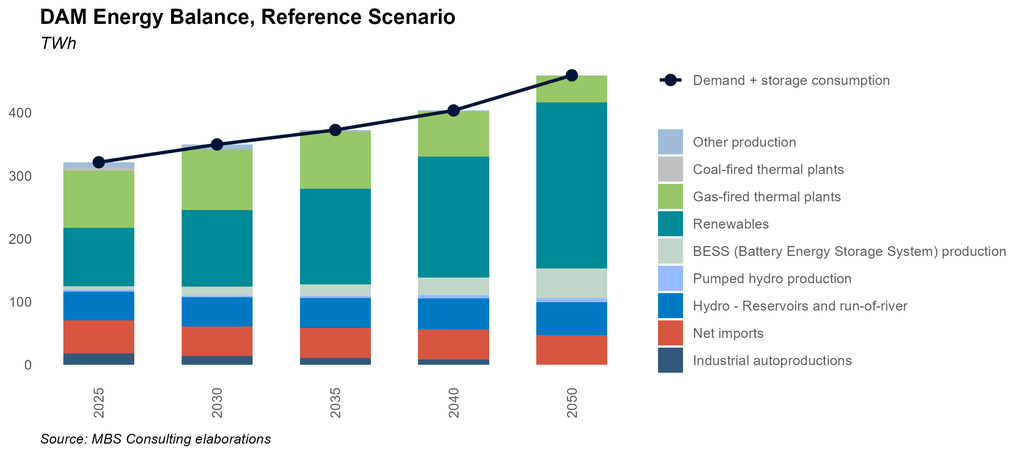

#### 25-26

Systemic overgeneration in Europe and PUN premium compared to European prices will jointly sustain imports from the Northern border. New renewable capacity will continue to grow through 2025–2026, though more slowly, while gas-fired plants remain the marginal source in the mix, amid slowly recovering demand.

#### 27-30

Coal-fired units are set to phase out by 2025, except for those in Sardinia, which are expected to remain operational until the Tyrrhenian Link is completed — projected for 2030 in the Reference case and 2028 in the High RES case. By 2030, RES are expected to meet about 51% of total electricity demand in the Reference case.

#### 31-50

Renewable energy is expected to account for 67% of the energy mix by 2040 and 81% by 2050. Gas-fired thermal plants are projected to represent about 11% of the mix by 2050. Supportive market dynamics are expected to drive the deployment of energy-intensive storage solutions, increasing their share of the energy mix to around 12% by 2050.

#### Main updates

Short- and mid-term power demand forecasts have been revised downward, as weak early-2025 demand and a struggling industrial sector point to a slow recovery. Other balance adjustments reflect updated commodity prices and revised RES-E output expectations.

### 5.1.2 High RES Scenario

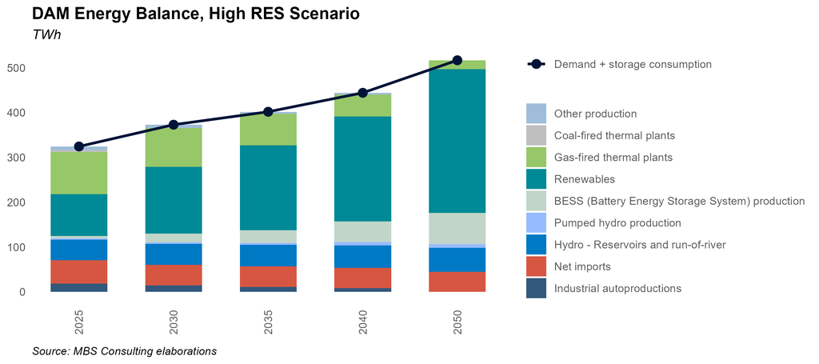

#### 25-26

In a context of moderate demand recovery, advancing RES installations, net imports exceeding 50 TWh, and the projected coal phase-out by 2025, the share of gas-fired generation in the mix is expected to stabilize at around 30% through 2026.

#### 27-30

By the end of 2028, coal-fired units are fully phased out. Declining renewable costs and the impact of regulated mechanisms — particularly FERX — support renewable development through 2030, while additional offshore wind projects come online. By 2030, the share of renewable energy in total electricity consumption reaches 56%, while net imports keep covering around 13% of the whole demand.

#### 31-50

In the long term, gas-fired thermal plants will remain essential for system security, but their share of the energy mix is expected to fall to 13% by 2040 and 5% by 2050 as storage capacity expands. Despite advances in storage and grid upgrades, full renewable integration will face challenges such as congestion and overproduction, underscoring the need for greater electrolyzer capacity to manage surplus renewable energy effectively.

#### Main updates

Short- and mid-term power demand forecasts have been revised downward, as weak early-2025 demand and a struggling industrial sector point to a slow recovery. Other balance adjustments reflect updated commodity prices and revised RES-E output expectations.

### 5.1.3 Low RES Scenario

**A SLOWER ECONOMIC RECOVERY LEADS TO LOWER ELECTRICITY DEMAND AND WEAKER INVESTMENT IN DECARBONIZATION. COMPLETION OF CRITICAL GRID PROJECTS ENABLES COAL PHASE-OUT BY 2032, WHILE RENEWABLES AND BATTERY STORAGE STEADILY INCREASE THEIR SHARE IN THE ENERGY MIX**

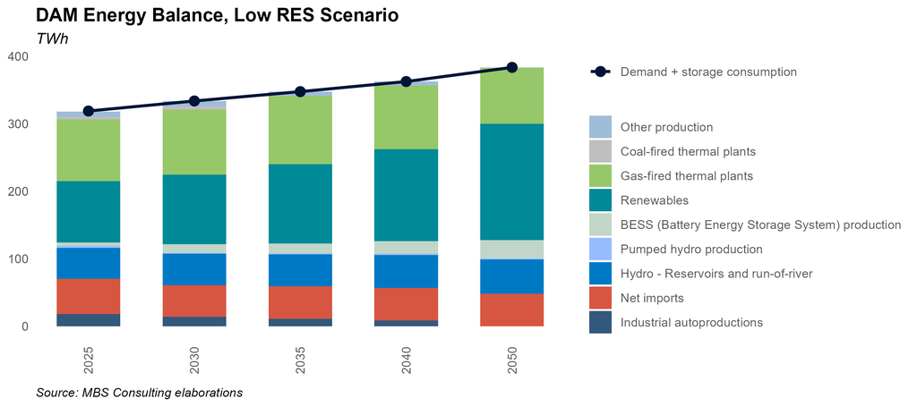

#### 25-26

As the role of coal-fired thermal plants in the energy mix declines and electricity demand grows toward 315 TWh, gas-fired plants are expected to continue covering over 30% of demand. Renewable generation is projected to rise annually, albeit at a moderate pace, due to a slowdown in new installations. Net electricity imports are anticipated to stabilize around 52 TWh by 2025.

#### 31-50

The complete phase-out of coal-fired plants is expected by 2032 with the commissioning of the Tyrrhenian Link. In parallel, gas-fired generation is projected to decline, covering just 23% of the energy mix by 2050. Shifting Day-Ahead Market dynamics and growing renewables—exceeding 60% of demand—will favour the integration of 14 GW of energy-intensive storage from 2031 to 2050.

#### Main updates

Short- and mid-term power demand projections have been revised downward from the previous update, as weaker-than-expected demand in the first eight months of 2025 and a deteriorating industrial sector point to a slow recovery in base demand. Although EV market performance in 2025 has exceeded expectations, meeting NIECP targets would require an unlikely surge in registrations, further justifying the downward mid-term demand revision. Other generation mix changes reflect updated short-term commodity price assumptions and revised mid-term RES output expectations.

## 5.2 Electricity Demand

**SHORT-TERM POWER DEMAND TRENDS REMAIN WEAK AMID SIGNS OF INDUSTRIAL SECTOR UNDERPERFORMANCE AND UNCERTAINTY IN THE GROWTH OF NEW CONSUMPTION SEGMENTS (EVs, HEAT PUMPS AND DATACENTRES). HOWEVER, DEMAND IS EXPECTED TO RISE IN THE MEDIUM TO LONG TERM, POTENTIALLY SURPASSING THE PRE-CRISIS LEVEL OF 320 TWh BY 2028 IN THE REFERENCE SCENARIO. A DETERIORATING CONTEXT COULD DELAY FULL RECOVERY UNTIL 2031**

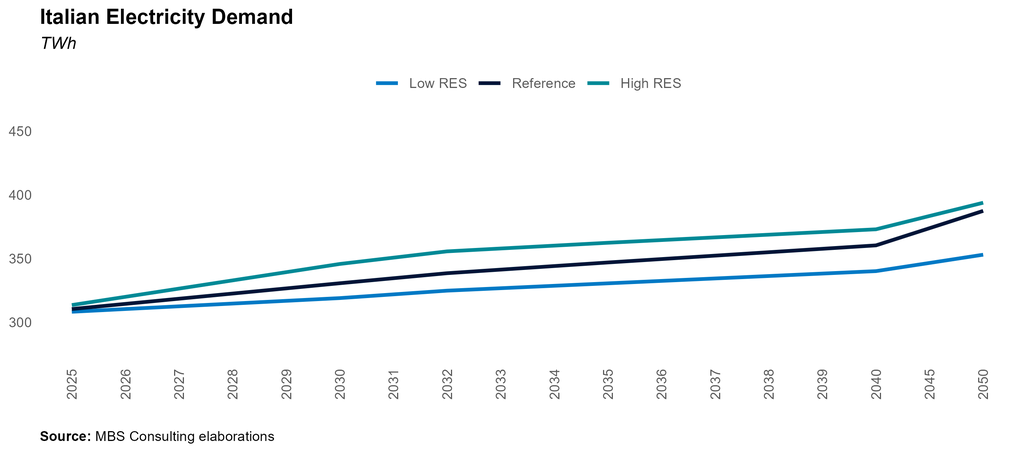

#### 25-26

A modest rise in base demand (+1 TWh annually), combined with an additional 2 TWh from EVs, heat pumps, and datacentres over the next two years, is expected to lift electricity demand to 315 TWh in the reference case by 2026. In the high RES scenario, stronger economic growth and a more optimistic outlook for EV registrations push demand above 320 TWh as early as 2026, while in the low RES scenario, a stagnant economy could keep demand below 320 TWh until 2031.

#### 31-50

After 2030, increased electrification in transport, heating, and data centres is expected to lift electricity demand, though efficiency gains may limit growth. In the reference case, demand rises to over 360 TWh by 2040 and stabilises near 385 TWh. Scenarios diverge thereafter: the high RES case exceeds 390 TWh by 2050, while the low RES case levels around 350 TWh.

#### Main updates

Short- and mid-term demand projections across all scenarios have been revised down, as weak demand in early 2025 and a deteriorating industrial sector signal a slow recovery. Despite stronger-than-expected EV sales, meeting NIECP targets would require an unlikely surge in registrations, reinforcing the downward revision.

### 5.2.1 E-mobility

**ADDITIONAL ELECTRICITY DEMAND FROM ELECTRIC VEHICLES (EVS) CAN VARY SIGNIFICANTLY DEPENDING ON THE FUTURE IMPLEMENTATION OF E-MOBILITY SOLUTIONS IN URBAN AREAS, EMISSIONS REDUCTION TARGETS IN TRANSPORTATION, AND OVERALL LONG-TERM TRANSPORTATION HABITS**

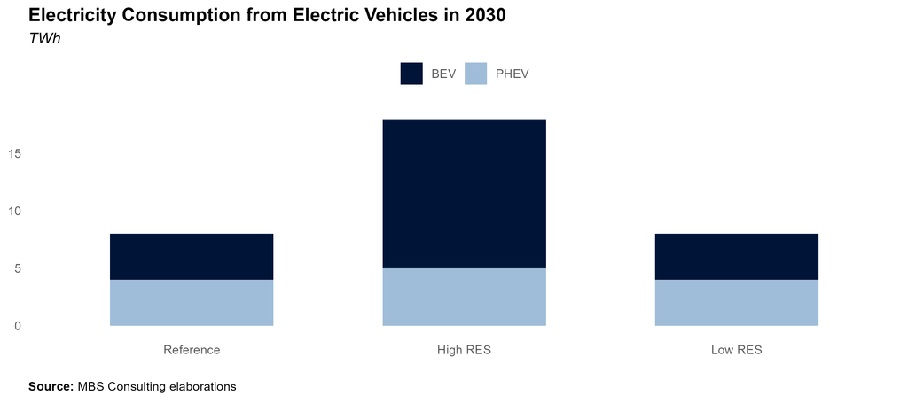

#### 25-40

Electric vehicle (EV) numbers are projected to reach 1.2 million by 2025, 4.1 million by 2030, and 10.7 million by 2040 in the reference scenario, translating into EV consumption of 2 TWh, 8.4 TWh, and 22.8 TWh, respectively. In the high RES scenario, faster electric vehicle uptake is expected, with 6.6 million by 2030 and 12.6 million by 2040. Conversely, in the low RES scenario, e-mobility deployment faces a 5- to 10-year delay versus the reference, and the PNIEC Slow Policy target of 4.5 million EVs is only reached by 2040.

#### 30

The NIECP targets 6.5 million electric vehicles in Italy by 2030 — 4.3 million of them pure EVs (BEVs: Battery Electric Vehicles). Our reference projections for 2030 remain below this policy goal, as current business-as-usual registrations average about +110k EVs per year, far from the +880k annual pace needed to meet the target. The high RES scenario, however, anticipates achieving the 6.5 million objective on schedule.

#### 31-50

Despite the recent Green Deal proposals at the EU level regarding transportation, the uncertainty surrounding the future expansion of a market still in its early stages of development leads us to assume a business-as-usual (BAU) trend over the long term, beginning with the annual level of electric vehicle (EV) additions projected for 2030.

#### Main updates

E-mobility demand have been revised to incorporate the recent evolutions in the market: 2024 signalled a sub-expectations evolution of EV registrations, while 2025 registered a significant % increase compared to the 2024 levels. Recent registration pace results still limited compared to the one needed to achieve policy targets.

### 5.2.2 Heating and Cooling

**THE ADDITIONAL ELECTRICITY DEMAND FOR HEATING AND COOLING WILL DEPEND ON THE GROWTH RATE OF INSTALLATIONS FOR RESIDENTIAL AND INDUSTRIAL USES, WHICH MAY BE FURTHER SUPPORTED BY DECARBONIZATION INCENTIVES**

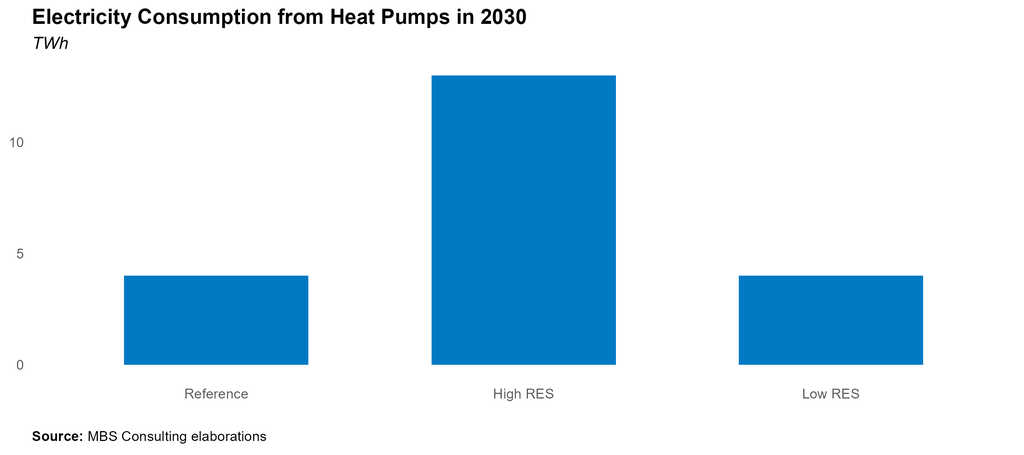

#### 25-40

Heating and cooling (H&C) is projected to represent additional electricity requirements ranging from 2 TWh to 5 TWh in 2025, 4 TWh to 13 TWh in 2030, and 8 TWh to 17 TWh in 2040, depending on the scenario analyzed.

#### 31-50

We assume a BAU trend in the long-term horizon, starting from the annual level of additional installations and consumption reached in 2030.

#### Main updates

H&C demand hypotheses are in line with the previous update.

### 5.2.3 Industrial Self-Production and Self-Consumption

**INDUSTRIAL SELF-CONSUMPTION WILL GRADUALLY DECREASE AS EXISTING ASSETS REACH END-OF-LIFE AND THE EXEMPTIONS ACCORDED TO CLOSED DISTRIBUTION SYSTEMS WILL BE AT LEAST PARTIALLY REMOVED**

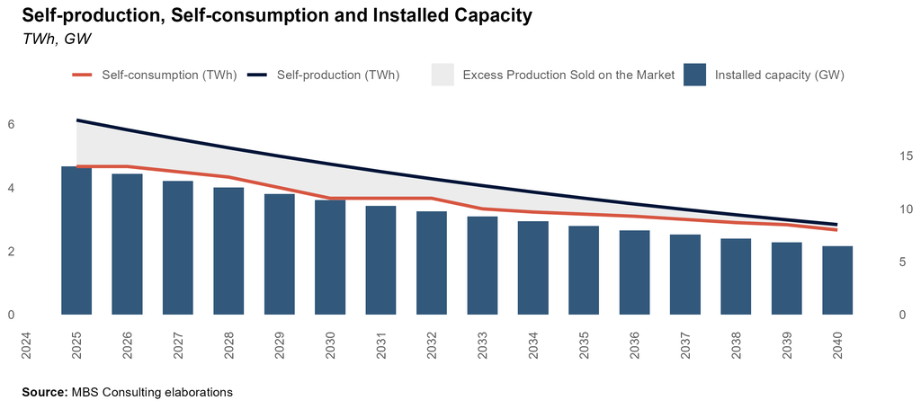

#### 25

Law 91/2014 affirms that grid and general system tariff components should be applied to the electricity consumed and not only to the electricity withdrawn from the public grid. Following this approach, the exemptions accorded to RIU (Re Interne di Utenza) and SEU (Sistemi Efficienti di Utenza) and closed distribution systems, and the benefits currently in force for existing plants related to self-consumption will be at least partially removed for new subjects/projects that apply for similar mechanisms.

#### 26-50

The excess of self-produced electricity that is not consumed by the industrial sites (self-consumption) and is thus sold on the market (differential between self-production and self-consumption) is expected to gradually decrease, consistently with the expected end-of-life of existing power plants that serve industrial sites.

#### Main updates

Industrial self-production and self-consumption hypotheses are in line with the previous update. Self-production/consumption hypotheses are the same in all the three scenarios.

### 5.2.4 Zonal Distribution of Electricity Demand

**ZONAL DISTRIBUTION OF ELECTRICITY DEMAND IS ESTIMATED IN LINE WITH MOST RECENT REGIONAL TRENDS**

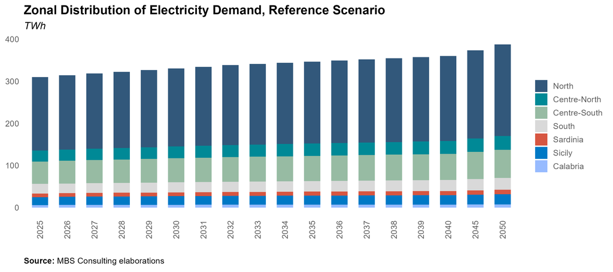

#### 15-20

In 2015, the approval of the European guidelines on capacity allocation and congestion management (CACM) introduced new parameters to be followed in the zonal configuration review process. In 2018, Terna began a process to review the zonal configurations in compliance with such rules.

#### 21-onwards

The current zonal configuration derives from the base case proposed by Terna in compliance with the CACM. Differences compared to the previous configuration: (i) elimination of the limited production poles, (ii) inclusion of a new bidding zone corresponding to the Calabria region, (iii) displacement of the Umbria region from the Centre-North zone to the Centre-South market zone.

#### 25-50

The zonal distribution of electricity demand is based on historical regional data published by Terna and subsequent econometric elaborations. In the Reference case, the zonal distribution of electricity needs is as follows: North (57%), Central-North (9%), Central-South (17%), South (7%), Calabria (2%), Sicily (6%), Sardinia (3%). Slight differences in such figures between the alternative cases are the result of the econometric elaborations performed.

#### Main updates

The approach adopted and the distribution quotas are in line with the previous update.

## 5.3 Net Import

**THE RECOVERY OF NUCLEAR CAPACITY FROM O&M OPERATIONS INITIATED IN 2022 (ALONG WITH THE CONNECTION OF THE FLAMANVILLE REACTOR AFTER LONG DELAYS), INCREASED HYDROPOWER PRODUCTION IN SWITZERLAND, AND LOWER ELECTRICITY DEMAND ACROSS EUROPE, IS EXPECTED TO SUSTAIN NET IMPORTS INTO THE NORTHERN ZONE. NET IMPORTS ARE PROJECTED TO REACH 50 TWH BY THE END OF 2024. AFTER 2029, THE COMPLETION OF A 600 MW INTERCONNECTOR WITH TUNISIA WILL ENHANCE EXPORT CAPABILITIES**

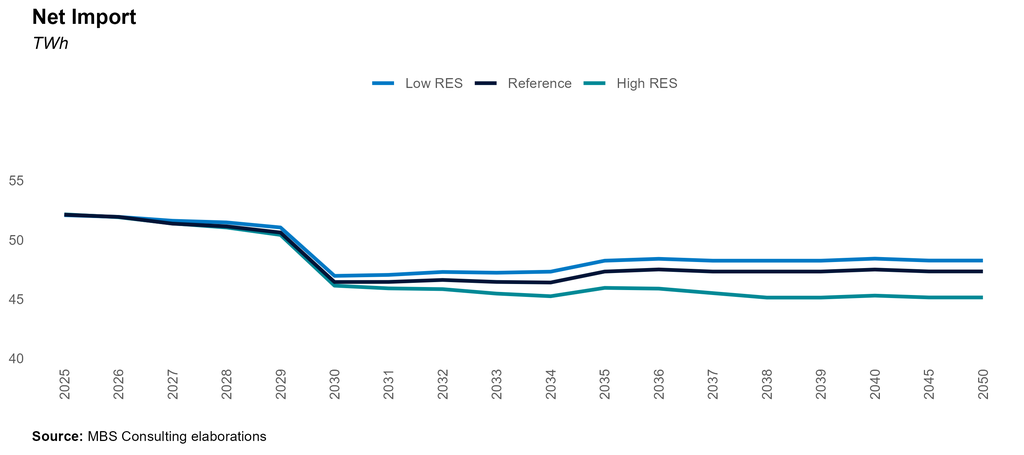

#### 25-26

Building on trends seen in 2023 and 2024, with net imports exceeding 50 TWh, imports from neighboring countries are expected to remain above historical averages in the short term. This sustained level is mainly driven by the gradual recovery of French nuclear output after two years of disruptions, increased hydroelectric production in Switzerland, and a slower-than-expected rebound in European electricity demand. Net imports are projected at 52.1 TWh in 2025, with a marginal decline of 200 GWh in 2026, representing 17% of short-term electricity demand.

#### 27-30

A moderate recovery in electricity demand, coupled with growing renewable capacity across Europe, fuels expectations of overgeneration in the medium term—positioning imports as a cost-effective option for Italy. This trend is supported by projections that the PUN will remain above other European price benchmarks. Net imports are forecast to average around 51 TWh annually through 2029. However, with the Elmed interconnection to Tunisia set to begin operation by late 2028, the net import balance is projected to decline to 47 TWh, as over 3.5 TWh shifts to exports.

#### 31-50

Import levels are expected to remain stable also after 2030, ranging above 47 TWh. The slight increase in net import seen from 2035 is due to an estimated reduction (1 TWh ca.) in the export flows towards Tunisia, following the implementation of the Tunisian system development plan.

#### Main updates

Import projections are in line with the previous update.

## 5.4 Thermoelectric Generation

### 5.4.1 Installed Capacity, Reference Scenario

**CAPACITY MARKET AUCTIONS WILL COMPREHENSIVELY BRING 4.5 GW OF NEW GAS-FIRED CAPACITY BY THE BEGINNING OF 2027. SARDINIAN COAL-FIRED UNITS TO BE PHASED-OUT ONLY IN 2029, CONSIDERING THE TYRRHENIAN LINK ENTERING IN 2030**

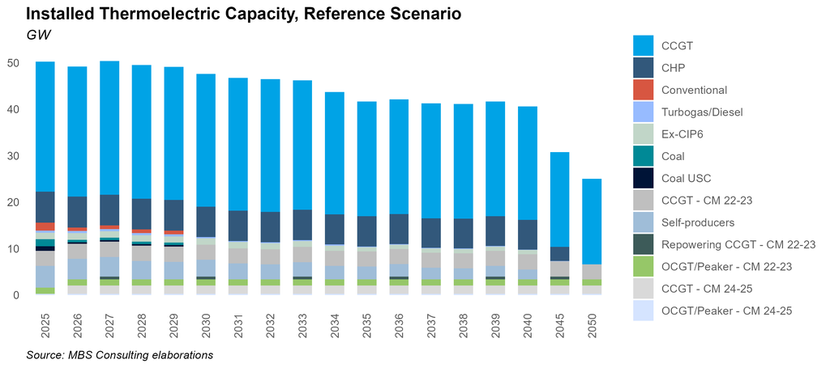

#### 25-26

Capacity secured in the 2024 Capacity Market auctions has experienced widespread delays, with notable examples such as the CCGT Ostiglia project now rescheduled for commissioning in February 2026. Most of this capacity is expected to gradually enter the market over the course of 2025.

#### 27-30

Auction results show also that Sardinia coal-fired capacity will not be substituted by gas-fired units, as only storage capacity was awarded in the island. Anyway, while coal-fired plants on the peninsula will be phased-out after 2025, Sardinia units are expected to operate until the Tyrrhenian Link infrastructure is fully completed (2030).

#### 31-50

The amount of capacity auctioned through the CM is expected to ensure full system adequacy until at least 2030. The latest CM auctions (delivery period 2025-2026-2027) have not provided the right signals for investment in new thermoelectric capacity, as new capacity awarded was related only to repowering and BESS, and no other investments are envisaged. Existing CHP plants continue to support industrial activities under the assumption of BAU evolution of industrial needs. Some obsolete CCGT capacity exits the market.

#### Main updates

Thermoelectric capacity assumptions are in line with the previous update.

### 5.4.2 Installed Capacity, High RES Scenario

[figure not shown]

#### 25-26

Capacity secured in the 2024 Capacity Market auctions has experienced widespread delays, with notable examples such as the CCGT Ostiglia project now rescheduled for commissioning in February 2026. Most of this capacity is expected to gradually enter the market over the course of 2025.

#### 31-50

The latest CM auctions (delivery period 2025-2026-2027) have not provided the right signals for investment in new thermoelectric capacity, as new capacity awarded was related only to repowering and BESS, and no other investments are envisaged. Most of existing CHP power plants gradually exit the market, substituted by greener solutions. Some ageing CCGT capacity exit the market following strong competitive conditions.

#### Main updates

Thermoelectric capacity assumptions are in line with the previous update.

### 5.4.3 Installed Capacity, Low RES Scenario

[figure not shown]

#### 25-26

Capacity secured in the 2024 Capacity Market auctions has experienced widespread delays, with notable examples such as the CCGT Ostiglia project now rescheduled for commissioning in February 2026. Most of this capacity is expected to gradually enter the market over the course of 2025.

#### 27-30

Thermal capacity expected to be stable in the second half of the decade in the Low RES scenario.

#### 31-50

The latest CM auctions (delivery period 2025-2026-2027) have not provided the right signals for investment in new thermoelectric capacity, as new capacity awarded was related only to repowering and BESS, and no other investments are envisaged. Existing CHP and CCGT power plants are projected to remain operative. The commissioning of the Tyrrhenian Link is postponed until 2032, determining a delayed phase-out of all coal power plants.

#### Main updates

Thermoelectric capacity assumptions are in line with the previous update.

### 5.4.4 Residual Demand for CCGTs

**EXISTING CCGTS STABILIZE AROUND 1,800 EOH IN 2025, THEN GRADUALLY DECLINE TOWARD 800 AVERAGE EOH BY 2040. THIS TREND IS DRIVEN BY A SIGNIFICANT RISE IN OUTPUT FROM NEW RENEWABLE ENERGY INSTALLATIONS, ALONGSIDE INCREASED COMPETITION FROM ADDITIONAL CAPACITY INTRODUCED FOLLOWING THE 2024–2025 CAPACITY MARKET AUCTIONS**

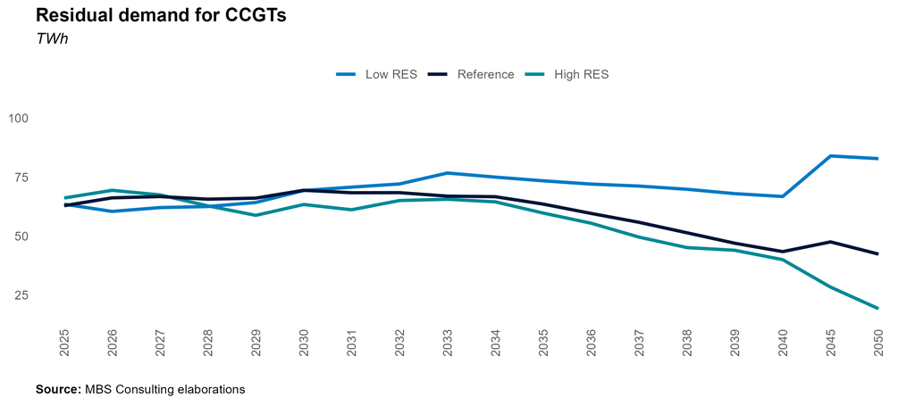

#### 31-50

Existing CCGTs (53%-efficiency) stabilize around 1200 EOH. In the High RES scenario, the great renewable penetration influences competitive dynamics and existing units remain close to 1000 EOH. In the Low RES scenario, the improvement of switching conditions is hampered by the high level of imports from abroad, with EOH of existing units over 2000 favored by phase-out after 2035. High-efficiency units stabilize below the 4800 EOH only in the Low scenario.

#### Main updates

CCGT residual demand projections have been revised downward due to lower power demand expectations and higher projected RES-E output.

### 5.4.5 Coal-fired Production

**THE PHASE-OUT OF COAL-FIRED THERMAL PLANTS IS EXPECTED TO OCCUR IN 2025, EXCEPT FOR THE SARDINIAN PLANTS, WHICH ARE SET TO CLOSE THROUGH 2029. THIS TIMELINE COINCIDES WITH THE FULL COMPLETION OF THE TYRRHENIAN LINK IN 2030**

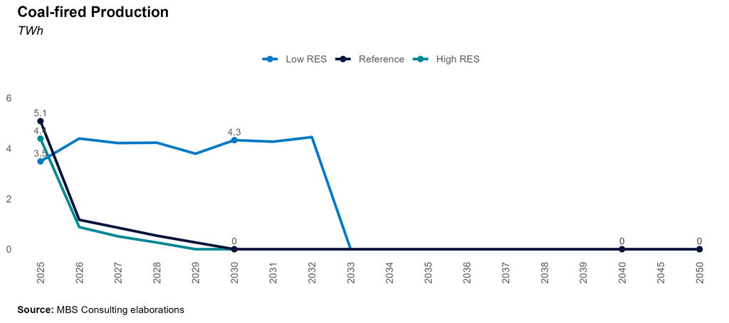

#### 25-26

Limited growth in electricity demand, combined with favorable switching conditions, sustained imports, and increasing RES-E generation, is expected to drive a significant reduction in coal production. In the Reference Scenario, coal output is projected to get to 5.1 TWh by 2025, while in the High RES Scenario, it falls further to just below 1 TWh by 2026. Conversely, in the Low RES Scenario, coal remains above 4 TWh by 2026.

#### 31-50

Coal units remain operational beyond 2030 only in the Low RES Scenario, with a complete phase-out projected by 2032, following the commissioning of the Tyrrhenian Link.

#### Main updates

Short-term changes in coal production reflect updated commodity prices, while the phase-out timeline is in line with the previous update.

## 5.5 Reneweable Generation

### 5.5.1 Renewable Installed Capacity

**RES CAPACITY GROWTH IS SET TO CONTINUE IN THE SHORT TERM, THOUGH SLOWER THAN 2024. LONG TERM, MARKET PARITY WILL BE DRIVEN BY HIGHER COMMODITY PRICES AND DECARBONIZATION POLICIES, BUT NIECP TARGETS ARE EXPECTED TO BE REACHED WITH A DELAY OF 4–5 YEARS**

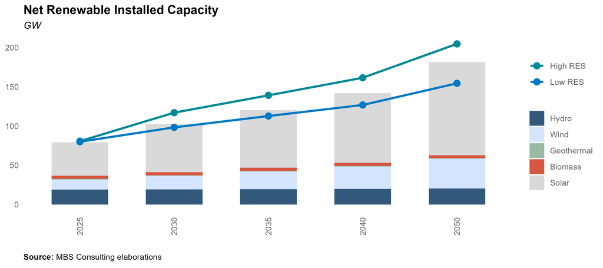

#### 25-26

By the end of 2025, 43 GW of solar and 14 GW of wind capacity are expected to be operational. In 2026, an additional 4.2 GW of solar and 660 MW of wind are projected in the Reference case, while in the High RES case, yearly additions could reach up to 7.5 GW. Installations align with the trend observed in the first eight months of 2025, showing steady PV growth but a slowdown from 2024, as developers delayed project deployment to participate in FERX and FERX Transitorio auctions amid regulatory adjustments and delays.

#### 27-30

Market parity, incentive schemes, and the solid progress in permitting achieved in 2024 and 2025 are expected to support deployment beyond 2025–2026. The Reference scenario projects 61 GW of solar and 18 GW of wind by 2030. In the High RES scenario, faster cost reductions and stronger economics raise solar to 72 GW and wind to 21 GW, with offshore wind accounting for over 50% of additions between 2027 and 2030.

#### Main updates

Solar capacity projections have been revised to better capture the momentum seen in Q1 and Q2 2025 — particularly with an upward adjustment of short-term PV installations, but also more broadly across the full horizon, as the 2025 installation slowdown versus 2024 proves less pronounced than expected.

### 5.5.2 Renewable Production

**THE EARLY MONTHS OF 2025 SHOWED STRONG SOLAR GROWTH, DRIVEN BY NEW CAPACITY AND CONSISTENTLY OUTPERFORMING 2024 LEVELS. YET, ACHIEVING ITALY’S NECP TARGETS WILL REQUIRE SIGNIFICANT EFFORT. MEETING THE 2030 RES/GDC GOAL OF 63% DEPENDS ON FASTER PERMITTING AND MORE STABLE WIND OUTPUT, WHICH REMAINS HIGHLY VARIABLE, WITH 2025 LEVELS BELOW 2024 DESPITE ADDITIONAL CAPACITY**

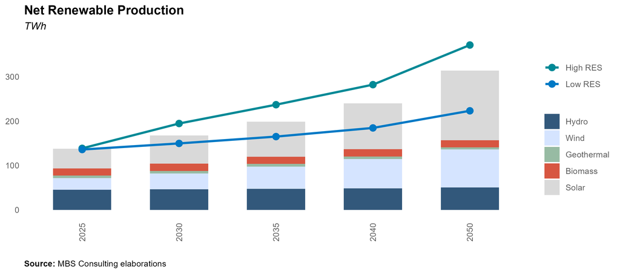

#### 25-26

Wind generation is expected to exceed 26.5 TWh, while solar is projected to reach nearly 44.5 TWh in 2025; combined output is expected to grow by an additional 6 TWh in 2026. In the High RES scenario, stronger demand and faster deployment push wind to 31 TWh and solar close to 49 TWh by 2026.

#### 27-30

Assuming business-as-usual producibility and steady installation growth beyond 2026, RES are expected to cover over 50% of demand by 2030 — about 80% of the 2030 target. Achieving a 63% RES share of gross domestic consumption by 2030 would require a much steeper green transition, with wind and solar capacity reaching NIECP target levels on time.

#### 31-50

In the reference scenario, reaching 2040 capacity targets by 2050 — supported by technological advances — would more than double wind and solar generation from 2025 levels. Offshore deployment, potentially adding up to 30 TWh by 2050, plays a pivotal role. Alternative scenarios show varying paths of renewable expansion and output.

#### Main updates

Short-term RES production forecasts have been slightly revised due to changes in solar installation trends.

### 5.5.3 Day-Ahead Market Overgeneration

**OVERGENERATION IS EXPECTED TO BECOME A SIGNIFICANT LONG-TERM CHALLENGE DUE TO HIGH RENEWABLE PENETRATION, PARTICULARLY IN SOUTHERN ZONES. SCALING UP ENERGY-INTENSIVE STORAGE AND ELECTROLYSIS CAPACITY WILL BE CRUCIAL TO MITIGATE MARKET IMBALANCES**

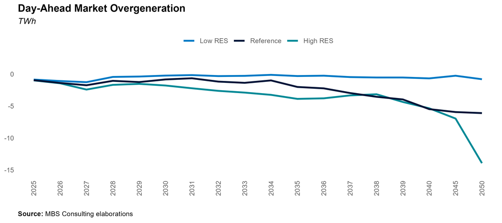

#### 25-26

Under BAU market conditions and sustained renewable growth, the risk of overgeneration remains limited in both the reference and low RES scenarios, averaging about 1.2 TWh. However, a sharper rise in capacity additions in the Southern macro-zone could cause more frequent overgeneration in the high RES scenario, though earlier grid infrastructure deployment keeps average overgeneration from exceeding 1.2 TWh.

#### 27-30

Advancing RES penetration is expected to raise the risk of overgeneration, while grid upgrades and demand recovery lag, causing overgeneration to peak in 2027. Rapid renewable expansion in southern regions and anticipated delays in grid reinforcement will keep average overgeneration around 1.2 TWh in the reference case and 1.8 TWh in the high RES case.

#### 31-50

Managing the challenges of rising renewable penetration and resulting overgeneration will require substantial investment in grid reinforcement and large-scale energy storage throughout the 2030s. These measures will be critical to maintaining grid stability, particularly in regions more exposed to overgeneration. At the same time, surplus electricity presents a strategic opportunity to expand electrolysis capacity, enabling productive use of excess energy and strengthening long-term renewable investment.

#### Main updates

Short-term day-ahead market overgeneration has changed following updates to RES production and power demand projections.

### 5.5.4 Electrolyzer Installed Capacity

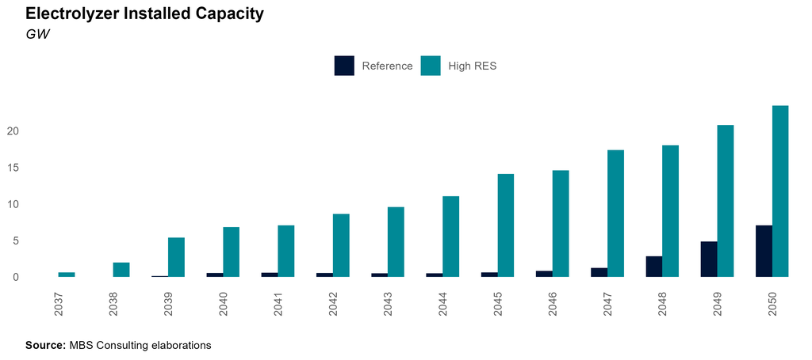

#### 35-40

In the long term, the expansion of renewable capacity—particularly in the Southern regions—is expected to significantly increase the incidence of systematic overgeneration, especially on the islands. Grid investments and battery energy storage systems (BESS) will likely prove inadequate to address this issue, thereby creating favorable conditions for the adoption of green hydrogen technologies. In the Reference scenario, installed electrolysis capacity could reach nearly 0.5 GW, predominantly concentrated in Sardinia. Over time, electrolysis capacity can effectively mitigate overgeneration by offering a mechanism to store surplus renewable energy. Moreover, by enhancing demand during periods of high RES production, it can help stabilize prices and alleviate the cannibalization effect, particularly during the later stages of the transition.

#### Main updates

Electrolyzer capacity hypotheses are in line with the previous update.

### 5.5.5 Solar Market Parity

**DESPITE THE EXPECTED LONG-TERM PRICE DECLINE—DRIVEN BY GAS MARKET STABILIZATION AND THE GRADUAL INTEGRATION OF RENEWABLES IN THE MIX SOLAR TECHNOLOGY REMAINS COMPETITIVE, WITH CAPTURED PRICES SURPASSING THE LEVELIZED COST OF ELECTRICITY**

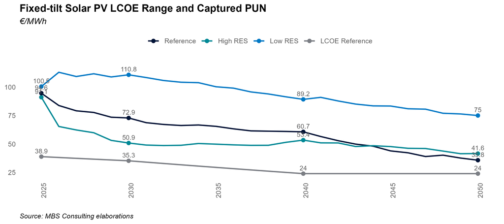

#### 27-30

Despite potential cannibalization effects on unlevered projects in Southern regions, falling investment costs and expected captured prices — projected between 69 and 78 €/MWh by 2030 in the Reference case — continue to sustain returns on PV plant investments.

#### 31-50

The long-term outlook for the renewable energy sector from 2030 onwards appears promising, driven by the continuous decline in technology costs and the adoption of enhanced Power Purchase Agreement (PPA) best practices, which are expected to bolster non-incentivized investments. However, the cannibalization effect may emerge as a significant concern in specific regions, such as Sardinia and Sicily, where the grid infrastructure may lack the capacity to efficiently manage and redirect energy flows.

#### Main updates

2025-2026 Solar captured prices reflect updated short-term commodity trends, while mid-term projections are influenced by revised demand outlooks and an updated hourly price shape — now more skewed than in the previous release due to additional historical data, with a deeper midday dip — driven by the growing share of solar generation in the energy mix.

### 5.5.6 Wind Market Parity

**DESPITE THE PROJECTED LONG-TERM PRICE DECLINE—DRIVEN BY GAS PRICE NORMALIZATION AND THE PROGRESSIVE INTEGRATION OF RENEWABLES INTO THE ENERGY MIX—WIND MARKET PARITY REMAINS SECURED THROUGH CAPTURED PRICES SURPASSING THE LEVELIZED COST OF ELECTRICITY**

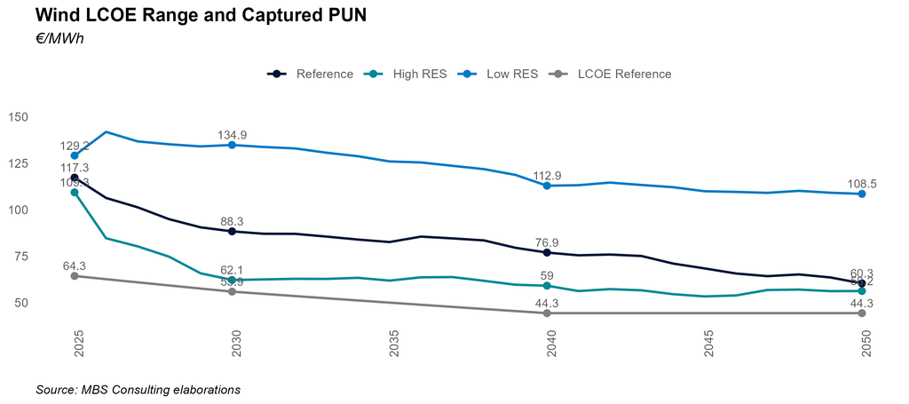

#### 27-30

The gradual reduction in investment costs for wind projects, combined with captured prices consistently above 80 €/MWh across all market zones, underpins wind market parity in the mid term. Price cannibalization effects are expected to remain limited until 2030, as significant capacity growth—partly driven by offshore expansion—is projected to accelerate in the 2030s. Nevertheless, site-specific conditions may continue to affect the economic performance of individual projects.

#### 31-50

The long-term outlook beyond 2030 appears promising, fueled by ongoing technology cost declines and the adoption of improved PPA practices that enable non-incentivized investments, further supported by the growing penetration of storage capacity. Captured prices are projected to stay consistently above 60 €/MWh through 2050, with the sole exception of the insular regions.

#### Main updates

2025-2026 Solar captured prices reflect updated short-term commodity trends, while mid-term projections are influenced by revised demand outlooks and an updated hourly price shape — now more skewed than in the previous release due to additional historical data, with a deeper midday dip — driven by the growing share of solar generation in the energy mix.

## 5.6 Storage

### 5.6.1 Pumped Hydro Production

**DAY-AHEAD MARKET OPPORTUNITIES FOR PUMPED HYDRO POWER PLANTS MAY EMERGE IN THE SHORT TERM DUE TO VOLATILE PRICE FLUCTUATIONS; THESE OPPORTUNITIES ARE EXPECTED TO PERSIST IN THE LONG TERM AS NON-PROGRAMMABLE RENEWABLE GENERATION CONTINUES TO GROW**

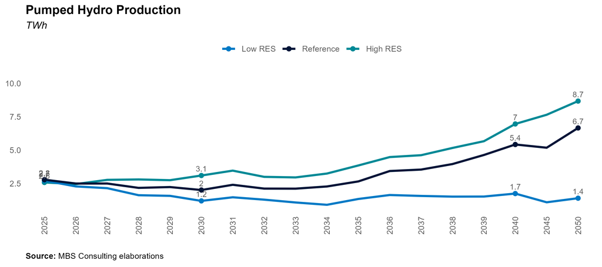

#### 25-26

Intra-day price spreads in the Day-Ahead Market (DAM) may create opportunities for pumped hydro units; however, the Ancillary Services Market — especially the real-time balancing phase — is expected to remain their main revenue source. Pumped hydro production is projected to average around 2.6 TWh in the reference case.

#### 27-30

With faster RES deployment and stronger demand growth than the BAU trajectory, pumped hydro production could reach 3.1 TWh by 2030 in the high RES scenario, supported by expanding DAM opportunities as RES penetration rises. Conversely, the low RES scenario would limit production to 1.2 TWh.

#### 31-50

As non-programmable renewables exceed 50% of total electricity demand, market opportunities are expected to expand further. Pumped hydro units will be key to mitigating the solar cannibalization effect and alleviating network congestion, with production projected to near 7 TWh by 2050.

#### Main updates

Short-term fluctuations in pumped hydro production reflect updated commodity prices, as well as revised RES generation and demand projections. Pure pumped hydro capacity currently stands at around 4 GW, with no further expansions expected going forward.

### 5.6.2 Battery Energy Storage System

**IN THE SHORT TERM, SMALL-SCALE SYSTEMS WILL AID SOLAR INTEGRATION, ESPECIALLY IN THE NORTH. UTILITY-SCALE ENTRY WILL BE SUPPORTED BY CAPACITY MARKET AUCTIONS AND FAST RESERVE PROJECTS. THE MAIN MARKET ACCELERATOR WILL BE MACSE (2028–2030), DRIVING LARGE-SCALE DEPLOYMENT IN THE SOUTH AND ISLANDS FOR RES INTEGRATION**

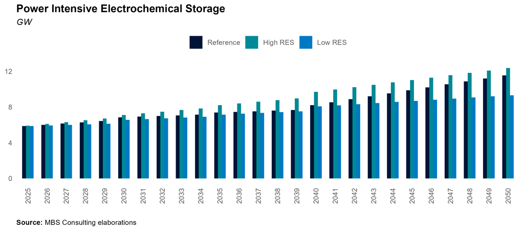

#### 25-26

In the coming years, projects from the December 2020 Fast Reserve auctions — part of Terna’s pilot for ultra-fast frequency regulation — are expected to enter operation. Additionally, the 2024 Capacity Market auction has spurred the development of energy-intensive storage in Italy and could bring four-hour systems to nearly 7 GWh by 2026. With continued distributed storage deployment, total electrochemical capacity could reach 18.9 GWh by 2026.

#### 27-30

Expanding storage capacity is vital for integrating non-programmable renewables and strengthening the stability of Italy’s electricity system. The NIECP targets 72 GWh of new storage by 2030, spanning both utility-scale and distributed projects, with the former largely concentrated in the South. A strong project pipeline is underway: by 2030, total BESS capacity is projected to reach 49–83 GWh across all scales, depending on the scenario. MACSE alone is expected to deliver over 30 GWh of utility-scale systems, with the 2025 auction already allocating its full 10 GWh quota to support this growth.

#### 31-50

Energy-intensive applications are expected to expand, driven by market signals from growing renewable capacity. In the Reference scenario, the 2030 NIECP targets are projected to be reached by the mid-2030s, with storage capacity climbing to 106 GWh by 2040 and rising further to 167 GWh in the high RES case.

#### Main updates

BESS capacity projections remain largely unchanged, still excluding the latest permitted pipeline, and the 2025 MACSE auction outcome.